# Analysis of Vowel Space

Tabea Thies

2022-09-13

# Analysis of Vowel Articulation Index (VAI) as measure of vowel space centralization

Load necessary packages

```r
library(tidyverse)
library(ggplot2)
library(lme4)
library(lmerTest)
library(merTools)
library(sjPlot)
```

Load data set

```r
data <- read_csv('../data/formants_VAI.csv')
```

# Create subset for the comparison Controls vs PD (in med-OFF)

```r
data_CON_PD <-  filter(data, med_con %in% c('med-OFF', 'CON'))
```

Descriptive stats for reporting values in Section 6.2.2

```r
VAI_stats <- data_CON_PD %>%
  group_by(med_con) %>%
  summarise(M = round(mean(VAI_meas,na.rm=T),2),
            SD = round(sd(VAI_meas,na.rm=T), 2))
VAI_stats
```

```
## # A tibble: 2 x 3
##   med_con     M    SD
##   <chr>   <dbl> <dbl>
## 1 CON      1     0.09
## 2 med-OFF  0.96  0.13
```

```r
VAI_stats2 <- data_CON_PD %>%
  group_by(med_con, focus_con) %>%
  summarise(M = round(mean(VAI_meas,na.rm=T),2),
            SD = round(sd(VAI_meas,na.rm=T), 2))
VAI_stats2
```

```
## # A tibble: 6 x 4
## # Groups:   med_con [2]
##   med_con focus_con       M    SD
##   <chr>   <chr>       <dbl> <dbl>
## 1 CON     background   0.98  0.08
## 2 CON     broad        1.01  0.1
## 3 CON     contrastive  1.02  0.09
## 4 med-OFF background   0.93  0.12
## 5 med-OFF broad        0.97  0.12
## 6 med-OFF contrastive  0.98  0.14
```

create linear mixed model

```r
set.seed(42)

mdl1 <- lmer(VAI_meas ~ med_con + focus_con + age + (1|speaker), data_CON_PD, REML = FALSE)
```

Look at model summary

```r
summary(mdl1)
```

```
## Linear mixed model fit by maximum likelihood . t-tests use Satterthwaite's
##   method [lmerModLmerTest]
## Formula: VAI_meas ~ med_con + focus_con + age + (1 | speaker)
##    Data: data_CON_PD
##
##      AIC      BIC   logLik deviance df.resid
##   -160.3   -143.8     87.2   -174.3       71
##
## Scaled residuals:
##      Min       1Q   Median       3Q      Max
## -2.64977 -0.52665  0.04194  0.63379  1.81671
##
## Random effects:
##  Groups   Name        Variance Std.Dev.
##  speaker  (Intercept) 0.008197 0.09054
##  Residual             0.002987 0.05465
## Number of obs: 78, groups:  speaker, 26
##
## Fixed effects:
##                        Estimate Std. Error         df t value Pr(>|t|)
## (Intercept)           0.9572296  0.1435749 26.1940977   6.667 4.34e-07 ***
## med_conmed-OFF       -0.0456759  0.0376077 25.9999983  -1.215  0.23546
## focus_conbroad        0.0394050  0.0151580 52.0000006   2.600  0.01212 *
## focus_concontrastive  0.0496184  0.0151580 52.0000006   3.273  0.00189 **
## age                   0.0002972  0.0023837 25.9999983   0.125  0.90175
## ---
## Signif. codes:  0 '***' 0.001 '**' 0.01 '*' 0.05 '.' 0.1 ' ' 1
##
## Correlation of Fixed Effects:
##             (Intr) m_-OFF fcs_cnb fcs_cnc
## md_cnmd-OFF -0.141
## focus_cnbrd -0.053  0.000
## fcs_cncntrs -0.053  0.000  0.500
## age         -0.981  0.010  0.000   0.000
```

Extracting fit statistics for reporting in text

```r
tab_model(mdl1)
```

|  | VAI meas |  |  |
| --- | --- | --- | --- |
| Predictors | Estimates | CI | p |
| (Intercept) | 0.96 | 0.67 – 1.24 | **<0.001** |
| med con [med-OFF] | -0.05 | -0.12 – 0.03 | 0.229 |
| focus con [broad] | 0.04 | 0.01 – 0.07 | **0.011** |
| focus con [contrastive] | 0.05 | 0.02 – 0.08 | **0.002** |
| age | 0.00 | -0.00 – 0.01 | 0.901 |
| Random Effects |  |  |  |
| σ<sup>2</sup> | 0.00 |  |  |
| τ<sub>00</sub> <sub>speaker</sub> | 0.01 |  |  |
| ICC | 0.73 |  |  |
| N <sub>speaker</sub> | 26 |  |  |
| Observations | 78 |  |  |
| Marginal R<sup>2</sup> / Conditional R<sup>2</sup> | 0.082 / 0.755 |  |  |

## Explore random effects with function REsim

Effects for individual levels are simulated  
Output: mean, median and sd of the random effect estimates

Plots estimated random effects for each participant  
95 % Intervals that do not overlap zero are bold

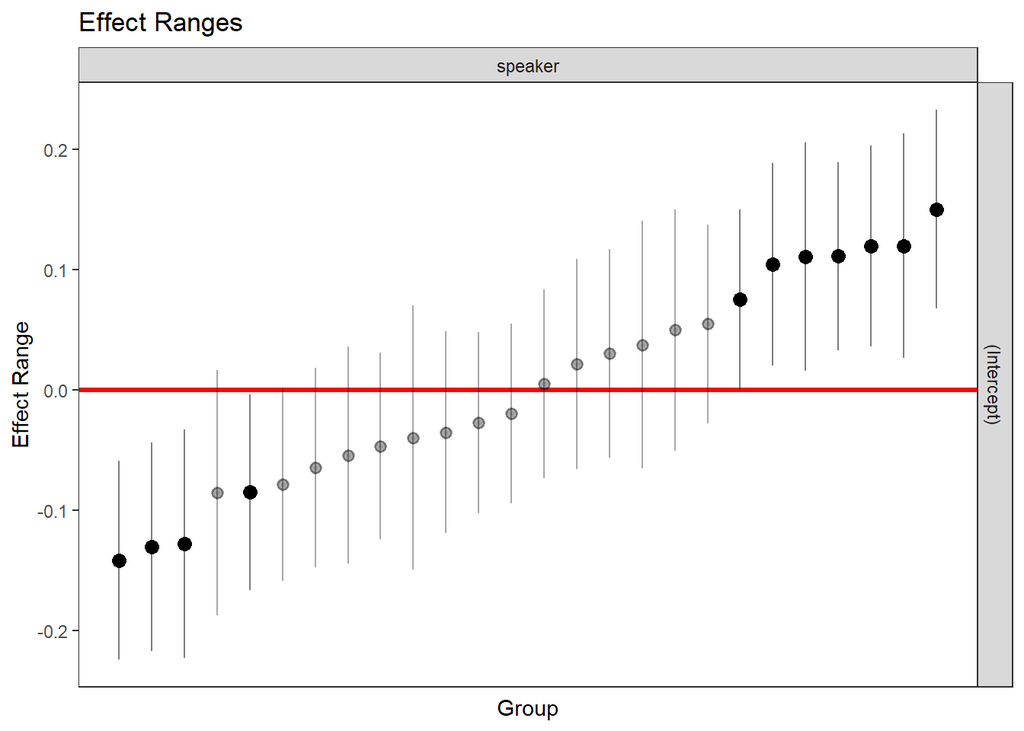

```r
randoms <- REsim(mdl1)
plotREsim(randoms)
```

Plot estimated 95 % interval spans for the intercept of VAI values

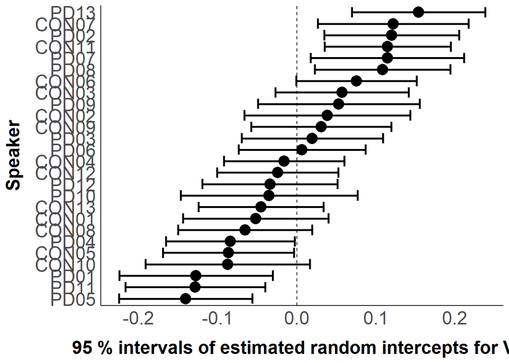

```r
random2 <- subset(randoms, term == "(Intercept)")

random2 %>%
  ggplot(aes(x = mean, xmin = mean-sd-sd, xmax = mean+sd+sd, y = reorder(groupID, mean))) +
  geom_vline(xintercept = 0, linetype = 'dashed') +
  geom_point(size = 5)+
  geom_errorbar(size = 1) +
  theme_classic()+
  xlab('95 % intervals of estimated random intercepts for VAI') +
  ylab('Speaker')+
  theme(axis.title.y = element_text(face = 'bold', size = 18, margin = margin(r = 12)))+
  theme(axis.title.x = element_text(face = 'bold', size = 18, margin = margin(t = 12)))+
  theme(strip.text.x = element_text(size=18, face="bold"),
        strip.background = element_blank())+
  theme(axis.text.x = element_text(size = 18),
        axis.text.y = element_text(size = 18)) +
  theme(axis.ticks.x = element_blank(),
        axis.ticks.y = element_blank())+
  theme(legend.position = "top",
        legend.title = element_blank(),
        legend.text = element_text(size = 18))
```

# Create subset for the comparison med-OFF vs med-ON

```r
data_DOPA <-  filter(data, med_con %in% c('med-OFF', 'med-ON'))
```

```r
VAI_stats <- data_DOPA %>%
  group_by(med_con) %>%
  summarise(M = round(mean(VAI_meas,na.rm=T),2),
            SD = round(sd(VAI_meas,na.rm=T), 2))
VAI_stats
```

```
## # A tibble: 2 x 3
##   med_con     M    SD
##   <chr>   <dbl> <dbl>
## 1 med-OFF  0.96  0.13
## 2 med-ON   0.95  0.08
```

```r
VAI_stats2 <- data_DOPA %>%
  group_by(med_con, focus_con) %>%
  summarise(M = round(mean(VAI_meas,na.rm=T),2),
            SD = round(sd(VAI_meas,na.rm=T), 2))
VAI_stats2
```

```
## # A tibble: 6 x 4
## # Groups:   med_con [2]
##   med_con focus_con       M    SD
##   <chr>   <chr>       <dbl> <dbl>
## 1 med-OFF background   0.93  0.12
## 2 med-OFF broad        0.97  0.12
## 3 med-OFF contrastive  0.98  0.14
## 4 med-ON  background   0.94  0.09
## 5 med-ON  broad        0.95  0.08
## 6 med-ON  contrastive  0.96  0.08
```

create linear mixed model

```r
set.seed(42)

mdl2 <- lmer(VAI_meas ~ med_con + focus_con + age + (1+med_con|speaker), data_DOPA, REML = FALSE)
```

Look at model summary

```r
summary(mdl2)
```

```
## Linear mixed model fit by maximum likelihood . t-tests use Satterthwaite's
##   method [lmerModLmerTest]
## Formula: VAI_meas ~ med_con + focus_con + age + (1 + med_con | speaker)
##    Data: data_DOPA
##
##      AIC      BIC   logLik deviance df.resid
##   -171.6   -150.3     94.8   -189.6       69
##
## Scaled residuals:
##      Min       1Q   Median       3Q      Max
## -2.88162 -0.39307 -0.06181  0.51938  2.10068
##
## Random effects:
##  Groups   Name          Variance Std.Dev. Corr
##  speaker  (Intercept)   0.011320 0.10639
##           med_conmed-ON 0.005386 0.07339  -0.76
##  Residual               0.002678 0.05175
## Number of obs: 78, groups:  speaker, 13
##
## Fixed effects:
##                        Estimate Std. Error         df t value Pr(>|t|)
## (Intercept)           9.390e-01  1.543e-01  1.363e+01   6.084 3.16e-05 ***
## med_conmed-ON        -7.285e-03  2.349e-02  1.300e+01  -0.310   0.7614
## focus_conbroad        2.438e-02  1.435e-02  5.200e+01   1.698   0.0954 .
## focus_concontrastive  3.589e-02  1.435e-02  5.200e+01   2.500   0.0156 *
## age                  -6.247e-06  2.563e-03  1.300e+01  -0.002   0.9981
## ---
## Signif. codes:  0 '***' 0.001 '**' 0.01 '*' 0.05 '.' 0.1 ' ' 1
##
## Correlation of Fixed Effects:
##             (Intr) md_-ON fcs_cnb fcs_cnc
## med_cnmd-ON -0.146
## focus_cnbrd -0.047  0.000
## fcs_cncntrs -0.047  0.000  0.500
## age         -0.979  0.000  0.000   0.000
```

Extracting fit statistics for reporting in text

```r
tab_model(mdl2)
```

|  | VAI meas |  |  |
| --- | --- | --- | --- |
| Predictors | Estimates | CI | p |
| (Intercept) | 0.94 | 0.63 – 1.25 | **<0.001** |
| med con [med-ON] | -0.01 | -0.05 – 0.04 | 0.757 |
| focus con [broad] | 0.02 | -0.00 – 0.05 | 0.094 |
| focus con [contrastive] | 0.04 | 0.01 – 0.06 | **0.015** |
| age | -0.00 | -0.01 – 0.01 | 0.998 |
| Random Effects |  |  |  |
| σ<sup>2</sup> | 0.00 |  |  |
| τ<sub>00</sub> <sub>speaker</sub> | 0.01 |  |  |
| τ<sub>11</sub> <sub>speaker.med_conmed-ON</sub> | 0.01 |  |  |
| ρ<sub>01</sub> <sub>speaker</sub> | -0.76 |  |  |
| ICC | 0.75 |  |  |
| N <sub>speaker</sub> | 13 |  |  |
| Observations | 78 |  |  |
| Marginal R<sup>2</sup> / Conditional R<sup>2</sup> | 0.022 / 0.756 |  |  |

Explore random effects with function REsim

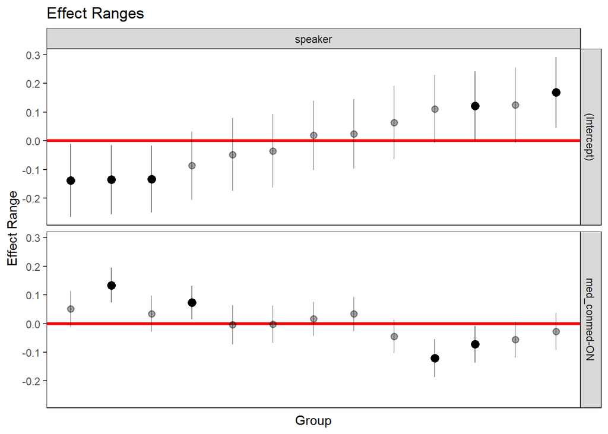

```r
randoms <- REsim(mdl2)
plotREsim(randoms)
```

Plot estimated 95 % interval spans for the intercept of VAI values

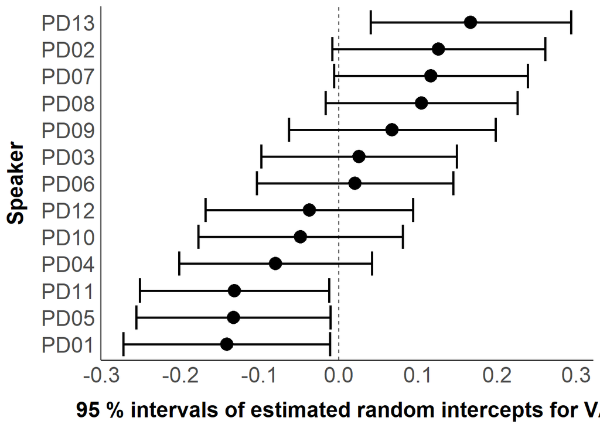

```r
random2 <- subset(randoms, term == "(Intercept)")

random2 %>%
  ggplot(aes(x = mean, xmin = mean-sd-sd, xmax = mean+sd+sd, y = reorder(groupID, mean))) +
  geom_vline(xintercept = 0, linetype = 'dashed') +
  geom_point(size = 5)+
  geom_errorbar(size = 1) +
  theme_classic()+
  xlab('95 % intervals of estimated random intercepts for VAI') +
  ylab('Speaker')+
  theme(axis.title.y = element_text(face = 'bold', size = 18, margin = margin(r = 12)))+
  theme(axis.title.x = element_text(face = 'bold', size = 18, margin = margin(t = 12)))+
  theme(strip.text.x = element_text(size=18, face="bold"),
        strip.background = element_blank())+
  theme(axis.text.x = element_text(size = 18),
        axis.text.y = element_text(size = 18)) +
  theme(axis.ticks.x = element_blank(),
        axis.ticks.y = element_blank())+
  theme(legend.position = "top",
        legend.title = element_blank(),
        legend.text = element_text(size = 18))
```

[figure not shown]

```r
random2 <- subset(randoms, term == "(Intercept)")

random2 %>%
  ggplot(aes(x = mean, xmin = mean-sd-sd, xmax = mean+sd+sd, y = reorder(groupID, mean))) +
  geom_vline(xintercept = 0, linetype = 'dashed') +
  geom_point(size = 5)+
  geom_errorbar(size = 1) +
  theme_classic()+
  xlab('95 % intervals of estimated random slopes for VAI') +
  ylab('Speaker')+
  theme(axis.title.y = element_text(face = 'bold', size = 18, margin = margin(r = 12)))+
  theme(axis.title.x = element_text(face = 'bold', size = 18, margin = margin(t = 12)))+
  theme(strip.text.x = element_text(size=18, face="bold"),
        strip.background = element_blank())+
  theme(axis.text.x = element_text(size = 18),
        axis.text.y = element_text(size = 18)) +
  theme(axis.ticks.x = element_blank(),
        axis.ticks.y = element_blank())+
  theme(legend.position = "top",
        legend.title = element_blank(),
        legend.text = element_text(size = 18))
```

# Create subset for the comparison med-OFF vs med-ON

```r
data_DOPA <-  filter(data, med_con %in% c('med-OFF', 'med-ON'))
```

Descriptive stats for reporting values in Section 7.2.2

```r
VAI_stats <- data_DOPA %>%
  group_by(med_con) %>%
  summarise(M = round(mean(VAI_meas,na.rm=T),2),
            SD = round(sd(VAI_meas,na.rm=T), 2))
VAI_stats
```

```
## # A tibble: 2 x 3
##   med_con     M    SD
##   <chr>   <dbl> <dbl>
## 1 med-OFF  0.96  0.13
## 2 med-ON   0.95  0.08
```

```r
VAI_stats2 <- data_DOPA %>%
  group_by(med_con, focus_con) %>%
  summarise(M = round(mean(VAI_meas,na.rm=T),2),
            SD = round(sd(VAI_meas,na.rm=T), 2))
VAI_stats2
```

```
## # A tibble: 6 x 4
## # Groups:   med_con [2]
##   med_con focus_con       M    SD
##   <chr>   <chr>       <dbl> <dbl>
## 1 med-OFF background   0.93  0.12
## 2 med-OFF broad        0.97  0.12
## 3 med-OFF contrastive  0.98  0.14
## 4 med-ON  background   0.94  0.09
## 5 med-ON  broad        0.95  0.08
## 6 med-ON  contrastive  0.96  0.08
```

create linear mixed model

```r
set.seed(42)

mdl2 <- lmer(VAI_meas ~ med_con + focus_con + age + (1+med_con|speaker), data_DOPA, REML = FALSE)
```

Look at model summary

```r
summary(mdl2)
```

```
## Linear mixed model fit by maximum likelihood . t-tests use Satterthwaite's
##   method [lmerModLmerTest]
## Formula: VAI_meas ~ med_con + focus_con + age + (1 + med_con | speaker)
##    Data: data_DOPA
##
##      AIC      BIC   logLik deviance df.resid
##   -171.6   -150.3     94.8   -189.6       69
##
## Scaled residuals:
##      Min       1Q   Median       3Q      Max
## -2.88162 -0.39307 -0.06181  0.51938  2.10068
##
## Random effects:
##  Groups   Name          Variance Std.Dev. Corr
##  speaker  (Intercept)   0.011320 0.10639
##           med_conmed-ON 0.005386 0.07339  -0.76
##  Residual               0.002678 0.05175
## Number of obs: 78, groups:  speaker, 13
##
## Fixed effects:
##                        Estimate Std. Error         df t value Pr(>|t|)
## (Intercept)           9.390e-01  1.543e-01  1.363e+01   6.084 3.16e-05 ***
## med_conmed-ON        -7.285e-03  2.349e-02  1.300e+01  -0.310   0.7614
## focus_conbroad        2.438e-02  1.435e-02  5.200e+01   1.698   0.0954 .
## focus_concontrastive  3.589e-02  1.435e-02  5.200e+01   2.500   0.0156 *
## age                  -6.247e-06  2.563e-03  1.300e+01  -0.002   0.9981
## ---
## Signif. codes:  0 '***' 0.001 '**' 0.01 '*' 0.05 '.' 0.1 ' ' 1
##
## Correlation of Fixed Effects:
##             (Intr) md_-ON fcs_cnb fcs_cnc
## med_cnmd-ON -0.146
## focus_cnbrd -0.047  0.000
## fcs_cncntrs -0.047  0.000  0.500
## age         -0.979  0.000  0.000   0.000
```

Extracting fit statistics for reporting in text

```r
tab_model(mdl2)
```

|  | VAI meas |  |  |
| --- | --- | --- | --- |
| Predictors | Estimates | CI | p |
| (Intercept) | 0.94 | 0.63 – 1.25 | **<0.001** |
| med con [med-ON] | -0.01 | -0.05 – 0.04 | 0.757 |
| focus con [broad] | 0.02 | -0.00 – 0.05 | 0.094 |
| focus con [contrastive] | 0.04 | 0.01 – 0.06 | **0.015** |
| age | -0.00 | -0.01 – 0.01 | 0.998 |
| Random Effects |  |  |  |
| σ<sup>2</sup> | 0.00 |  |  |
| τ<sub>00</sub> <sub>speaker</sub> | 0.01 |  |  |
| τ<sub>11</sub> <sub>speaker.med_conmed-ON</sub> | 0.01 |  |  |
| ρ<sub>01</sub> <sub>speaker</sub> | -0.76 |  |  |
| ICC | 0.75 |  |  |
| N <sub>speaker</sub> | 13 |  |  |
| Observations | 78 |  |  |
| Marginal R<sup>2</sup> / Conditional R<sup>2</sup> | 0.022 / 0.756 |  |  |

# Create subset for the comparison DBS-OFF vs DBS-ON

```r
data_DBS <-  filter(data, med_con %in% c('med-OFF/DBS-OFF', 'med-OFF/DBS-ON'))

data_DBS <- subset(data_DBS, speaker != "PD03")
```

Descriptive stats for reporting values in Section 8.2.2

```r
VAI_stats <- data_DBS %>%
  group_by(med_con) %>%
  summarise(M = round(mean(VAI_meas,na.rm=T),2),
            SD = round(sd(VAI_meas,na.rm=T), 2))
VAI_stats
```

```
## # A tibble: 2 x 3
##   med_con             M    SD
##   <chr>           <dbl> <dbl>
## 1 med-OFF/DBS-OFF  0.95  0.09
## 2 med-OFF/DBS-ON   0.94  0.09
```

```r
VAI_stats2 <- data_DBS %>%
  group_by(med_con, focus_con) %>%
  summarise(M = round(mean(VAI_meas,na.rm=T),2),
            SD = round(sd(VAI_meas,na.rm=T), 2))
VAI_stats2
```

```
## # A tibble: 6 x 4
## # Groups:   med_con [2]
##   med_con         focus_con       M    SD
##   <chr>           <chr>       <dbl> <dbl>
## 1 med-OFF/DBS-OFF background   0.93  0.11
## 2 med-OFF/DBS-OFF broad        0.95  0.09
## 3 med-OFF/DBS-OFF contrastive  0.96  0.09
## 4 med-OFF/DBS-ON  background   0.92  0.08
## 5 med-OFF/DBS-ON  broad        0.94  0.09
## 6 med-OFF/DBS-ON  contrastive  0.94  0.1
```

create linear mixed model

```r
set.seed(42)

mdl3 <- lmer(VAI_meas ~ med_con + focus_con + age + (1+med_con|speaker), data_DBS, REML = FALSE)
```

Look at model summary

```r
summary(mdl3)
```

```
## Linear mixed model fit by maximum likelihood . t-tests use Satterthwaite's
##   method [lmerModLmerTest]
## Formula: VAI_meas ~ med_con + focus_con + age + (1 + med_con | speaker)
##    Data: data_DBS
##
##      AIC      BIC   logLik deviance df.resid
##   -154.5   -134.0     86.3   -172.5       63
##
## Scaled residuals:
##      Min       1Q   Median       3Q      Max
## -2.22899 -0.51169  0.05904  0.57812  2.53211
##
## Random effects:
##  Groups   Name                  Variance Std.Dev. Corr
##  speaker  (Intercept)           0.005054 0.07109
##           med_conmed-OFF/DBS-ON 0.003120 0.05586  -0.54
##  Residual                       0.003280 0.05727
## Number of obs: 72, groups:  speaker, 12
##
## Fixed effects:
##                        Estimate Std. Error        df t value Pr(>|t|)
## (Intercept)            1.011662   0.135679 12.332892   7.456 6.54e-06 ***
## med_conmed-OFF/DBS-ON -0.010200   0.021030 12.000219  -0.485    0.636
## focus_conbroad         0.022281   0.016534 47.999827   1.348    0.184
## focus_concontrastive   0.023306   0.016534 47.999827   1.410    0.165
## age                   -0.001349   0.002249 12.000099  -0.600    0.560
## ---
## Signif. codes:  0 '***' 0.001 '**' 0.01 '*' 0.05 '.' 0.1 ' ' 1
##
## Correlation of Fixed Effects:
##             (Intr) m_-OFF fcs_cnb fcs_cnc
## m_-OFF/DBS- -0.095
## focus_cnbrd -0.061  0.000
## fcs_cncntrs -0.061  0.000  0.500
## age         -0.983  0.000  0.000   0.000
```

Extracting fit statistics for reporting in text

```r
tab_model(mdl3)
```

|  | VAI meas |  |  |
| --- | --- | --- | --- |
| Predictors | Estimates | CI | p |
| (Intercept) | 1.01 | 0.74 – 1.28 | **<0.001** |
| med con [med-OFF/DBS-ON] | -0.01 | -0.05 – 0.03 | 0.629 |
| focus con [broad] | 0.02 | -0.01 – 0.06 | 0.183 |
| focus con [contrastive] | 0.02 | -0.01 – 0.06 | 0.164 |
| age | -0.00 | -0.01 – 0.00 | 0.551 |
| Random Effects |  |  |  |
| σ<sup>2</sup> | 0.00 |  |  |
| τ<sub>00</sub> <sub>speaker</sub> | 0.01 |  |  |
| τ<sub>11</sub> <sub>speaker.med_conmed-OFF/DBS-ON</sub> | 0.00 |  |  |
| ρ<sub>01</sub> <sub>speaker</sub> | -0.54 |  |  |
| ICC | 0.58 |  |  |
| N <sub>speaker</sub> | 12 |  |  |
| Observations | 72 |  |  |
| Marginal R<sup>2</sup> / Conditional R<sup>2</sup> | 0.034 / 0.591 |  |  |

# Create subset for the comparison med-OFF vs DBS-OFF

```r
data_OFF <-  filter(data, med_con %in% c('med-OFF', 'med-OFF/DBS-OFF'))

data_OFF <- subset(data_OFF, speaker != "PD03")
```

Descriptive stats for reporting values in Section 10.2.2

```r
VAI_stats <- data_OFF %>%
  group_by(med_con) %>%
  summarise(M = round(mean(VAI_meas,na.rm=T),2),
            SD = round(sd(VAI_meas,na.rm=T), 2))
VAI_stats
```

```
## # A tibble: 2 x 3
##   med_con             M    SD
##   <chr>           <dbl> <dbl>
## 1 med-OFF          0.96  0.13
## 2 med-OFF/DBS-OFF  0.95  0.09
```

```r
VAI_stats2 <- data_OFF %>%
  group_by(med_con, focus_con) %>%
  summarise(M = round(mean(VAI_meas,na.rm=T),2),
            SD = round(sd(VAI_meas,na.rm=T), 2))
VAI_stats2
```

```
## # A tibble: 6 x 4
## # Groups:   med_con [2]
##   med_con         focus_con       M    SD
##   <chr>           <chr>       <dbl> <dbl>
## 1 med-OFF         background   0.93  0.13
## 2 med-OFF         broad        0.97  0.12
## 3 med-OFF         contrastive  0.97  0.14
## 4 med-OFF/DBS-OFF background   0.93  0.11
## 5 med-OFF/DBS-OFF broad        0.95  0.09
## 6 med-OFF/DBS-OFF contrastive  0.96  0.09
```

create linear mixed model

```r
set.seed(42)

mdl4 <- lmer(VAI_meas ~ med_con + focus_con + age + (1+med_con|speaker), data_OFF, REML = FALSE)
```

Look at model summary

```r
summary(mdl4)
```

```
## Linear mixed model fit by maximum likelihood . t-tests use Satterthwaite's
##   method [lmerModLmerTest]
## Formula: VAI_meas ~ med_con + focus_con + age + (1 + med_con | speaker)
##    Data: data_OFF
##
##      AIC      BIC   logLik deviance df.resid
##   -137.4   -116.9     77.7   -155.4       63
##
## Scaled residuals:
##     Min      1Q  Median      3Q     Max
## -1.9516 -0.4676  0.1031  0.4974  2.4630
##
## Random effects:
##  Groups   Name                   Variance Std.Dev. Corr
##  speaker  (Intercept)            0.013084 0.11439
##           med_conmed-OFF/DBS-OFF 0.005207 0.07216  -0.87
##  Residual                        0.004015 0.06337
## Number of obs: 72, groups:  speaker, 12
##
## Fixed effects:
##                         Estimate Std. Error        df t value Pr(>|t|)
## (Intercept)             0.780568   0.151329 13.056143   5.158 0.000182 ***
## med_conmed-OFF/DBS-OFF -0.011954   0.025701 12.128435  -0.465 0.650091
## focus_conbroad          0.030551   0.018292 47.999977   1.670 0.101392
## focus_concontrastive    0.036131   0.018292 47.999977   1.975 0.054009 .
## age                     0.002629   0.002508 12.119501   1.048 0.314993
## ---
## Signif. codes:  0 '***' 0.001 '**' 0.01 '*' 0.05 '.' 0.1 ' ' 1
##
## Correlation of Fixed Effects:
##             (Intr) m_-OFF fcs_cnb fcs_cnc
## m_-OFF/DBS- -0.112
## focus_cnbrd -0.060  0.000
## fcs_cncntrs -0.060  0.000  0.500
## age         -0.971 -0.073  0.000   0.000
```

Extracting fit statistics for reporting in text

```r
tab_model(mdl4)
```

|  | VAI meas |  |  |
| --- | --- | --- | --- |
| Predictors | Estimates | CI | p |
| (Intercept) | 0.78 | 0.48 – 1.08 | **<0.001** |
| med con [med-OFF/DBS-OFF] | -0.01 | -0.06 – 0.04 | 0.643 |
| focus con [broad] | 0.03 | -0.01 – 0.07 | 0.100 |
| focus con [contrastive] | 0.04 | -0.00 – 0.07 | 0.053 |
| age | 0.00 | -0.00 – 0.01 | 0.299 |
| Random Effects |  |  |  |
| σ<sup>2</sup> | 0.00 |  |  |
| τ<sub>00</sub> <sub>speaker</sub> | 0.01 |  |  |
| τ<sub>11</sub> <sub>speaker.med_conmed-OFF/DBS-OFF</sub> | 0.01 |  |  |
| ρ<sub>01</sub> <sub>speaker</sub> | -0.87 |  |  |
| ICC | 0.68 |  |  |
| N <sub>speaker</sub> | 12 |  |  |
| Observations | 72 |  |  |
| Marginal R<sup>2</sup> / Conditional R<sup>2</sup> | 0.058 / 0.698 |  |  |

# Create subset for the comparison med-OFF vs DBS-ON

for the analysis if DOPA and DBS effects are different to baseline (med-OFF)

```r
data_DBS2 <-  filter(data, med_con %in% c('med-OFF', 'med-OFF/DBS-ON'))
```

Descriptive stats for reporting values in Section 9.2.2

```r
VAI_stats <- data_DBS2 %>%
  group_by(med_con) %>%
  summarise(M = round(mean(VAI_meas,na.rm=T),2),
            SD = round(sd(VAI_meas,na.rm=T), 2))
VAI_stats
```

```
## # A tibble: 2 x 3
##   med_con            M    SD
##   <chr>          <dbl> <dbl>
## 1 med-OFF         0.96  0.13
## 2 med-OFF/DBS-ON  0.95  0.1
```

```r
VAI_stats2 <- data_DBS2 %>%
  group_by(med_con, focus_con) %>%
  summarise(M = round(mean(VAI_meas,na.rm=T),2),
            SD = round(sd(VAI_meas,na.rm=T), 2))
VAI_stats2
```

```
## # A tibble: 6 x 4
## # Groups:   med_con [2]
##   med_con        focus_con       M    SD
##   <chr>          <chr>       <dbl> <dbl>
## 1 med-OFF        background   0.93  0.12
## 2 med-OFF        broad        0.97  0.12
## 3 med-OFF        contrastive  0.98  0.14
## 4 med-OFF/DBS-ON background   0.94  0.1
## 5 med-OFF/DBS-ON broad        0.96  0.1
## 6 med-OFF/DBS-ON contrastive  0.96  0.11
```

create linear mixed model

```r
set.seed(42)

mdl5 <- lmer(VAI_meas ~ med_con + focus_con + age + (1+med_con|speaker), data_DBS2, REML = FALSE)
```

Look at model summary

```r
summary(mdl5)
```

```
## Linear mixed model fit by maximum likelihood . t-tests use Satterthwaite's
##   method [lmerModLmerTest]
## Formula: VAI_meas ~ med_con + focus_con + age + (1 + med_con | speaker)
##    Data: data_DBS2
##
##      AIC      BIC   logLik deviance df.resid
##   -160.9   -139.7     89.5   -178.9       69
##
## Scaled residuals:
##      Min       1Q   Median       3Q      Max
## -2.60175 -0.51504  0.00618  0.50358  2.20256
##
## Random effects:
##  Groups   Name                  Variance Std.Dev. Corr
##  speaker  (Intercept)           0.010952 0.10465
##           med_conmed-OFF/DBS-ON 0.004915 0.07010  -0.62
##  Residual                       0.003081 0.05551
## Number of obs: 78, groups:  speaker, 13
##
## Fixed effects:
##                        Estimate Std. Error        df t value Pr(>|t|)
## (Intercept)            1.052739   0.176836 13.588613   5.953 3.99e-05 ***
## med_conmed-OFF/DBS-ON -0.004582   0.023287 13.284024  -0.197   0.8470
## focus_conbroad         0.030540   0.015395 51.999744   1.984   0.0526 .
## focus_concontrastive   0.035093   0.015395 51.999744   2.279   0.0268 *
## age                   -0.001967   0.002953 13.238380  -0.666   0.5168
## ---
## Signif. codes:  0 '***' 0.001 '**' 0.01 '*' 0.05 '.' 0.1 ' ' 1
##
## Correlation of Fixed Effects:
##             (Intr) m_-OFF fcs_cnb fcs_cnc
## m_-OFF/DBS-  0.001
## focus_cnbrd -0.044  0.000
## fcs_cncntrs -0.044  0.000  0.500
## age         -0.984 -0.107  0.000   0.000
```

Extracting fit statistics for reporting in text

```r
tab_model(mdl5)
```

|  | VAI meas |  |  |
| --- | --- | --- | --- |
| Predictors | Estimates | CI | p |
| (Intercept) | 1.05 | 0.70 – 1.41 | **<0.001** |
| med con [med-OFF/DBS-ON] | -0.00 | -0.05 – 0.04 | 0.845 |
| focus con [broad] | 0.03 | -0.00 – 0.06 | 0.051 |
| focus con [contrastive] | 0.04 | 0.00 – 0.07 | **0.026** |
| age | -0.00 | -0.01 – 0.00 | 0.508 |
| Random Effects |  |  |  |
| σ<sup>2</sup> | 0.00 |  |  |
| τ<sub>00</sub> <sub>speaker</sub> | 0.01 |  |  |
| τ<sub>11</sub> <sub>speaker.med_conmed-OFF/DBS-ON</sub> | 0.00 |  |  |
| ρ<sub>01</sub> <sub>speaker</sub> | -0.62 |  |  |
| ICC | 0.74 |  |  |
| N <sub>speaker</sub> | 13 |  |  |
| Observations | 78 |  |  |
| Marginal R<sup>2</sup> / Conditional R<sup>2</sup> | 0.041 / 0.752 |  |  |